# Base de datos de virus de NCBI

Humberto Genaro Cisneros Salinas

2024-05-08

# } Base de datos de virus de NCBI

```r
library(rentrez)
library(seqinr)
library(Biostrings)
```

```r
library(ggplot2)
library(stringr)
```

## Entidades a Buscar

Zika virus, complete genome SARS coronavirus, complete genome

Wuhan seafood market pneumonia virus isolate Wuhan-Hu-1, complete genome

Middle East respiratory syndrome coronavirus, complete genome

Dengue virus 1, complete genome

Además, busca las secuencias de H1N1 que apareció en México en 2009 y obtén todos los segmentos del virus.

```r
zika<-readDNAStringSet("zika.fasta")[[1]]
sars<-readDNAStringSet("sars.fasta")[[1]]
wuhan<-readDNAStringSet("wuhan.fasta")[[1]]
middle_east<-readDNAStringSet("middleEast.fasta")[[1]]
dengue<-readDNAStringSet("dengue.fasta")[[1]]
h1n1<-readDNAStringSet("H1N1.fna")
```

## 1. ¿Cuál es el tamaño de cada secuencia?

### Zika

```r
print(length(zika))
```

```
## [1] 10808
```

### SARS coronavirus

```r
print(length(sars))
```

```
## [1] 29751
```

### Wuhan seafood market pneumonia virus isolate Wuhan-Hu-1

```r
print(length(wuhan))
```

```
## [1] 29903
```

### Middle East respiratory syndrome coronavirus

```r
print(length(middle_east))
```

```
## [1] 30119
```

### Dengue virus 1

```r
print(length(dengue))
```

```
## [1] 10735
```

### H1N1

```r
for(i in 1:length(h1n1)){
  cat(c("Longitud de Secuencia #",i,": ",length(h1n1[[i]]),"\n"))
}
```

```
## Longitud de Secuencia # 1 :  2280
## Longitud de Secuencia # 2 :  2274
## Longitud de Secuencia # 3 :  2151
## Longitud de Secuencia # 4 :  1701
## Longitud de Secuencia # 5 :  1497
## Longitud de Secuencia # 6 :  1410
## Longitud de Secuencia # 7 :  982
## Longitud de Secuencia # 8 :  863
```

## ¿Cúal es la composición de nucleótidos de cada secuencia?

### Zika

```r
print(alphabetFrequency(zika, baseOnly=TRUE, as.prob=TRUE))
```

```
##         A         C         G         T     other
## 0.2735011 0.2204848 0.2920984 0.2139156 0.0000000
```

### SARS coronavirus

```r
print(alphabetFrequency(sars, baseOnly=TRUE, as.prob=TRUE))
```

```
##         A         C         G         T     other
## 0.2850660 0.1996572 0.2079594 0.3073174 0.0000000
```

### Wuhan seafood market pneumonia virus isolate Wuhan-Hu-1

```r
print(alphabetFrequency(wuhan, baseOnly=TRUE, as.prob=TRUE))
```

```
##         A         C         G         T     other
## 0.2994348 0.1836605 0.1960673 0.3208374 0.0000000
```

### Middle East respiratory syndrome coronavirus

```r
print(alphabetFrequency(middle_east, baseOnly=TRUE, as.prob=TRUE))
```

```
##         A         C         G         T     other
## 0.2622929 0.2030612 0.2093031 0.3253428 0.0000000
```

### Dengue virus 1

```r
print(alphabetFrequency(dengue, baseOnly=TRUE, as.prob=TRUE))
```

```
##         A         C         G         T     other
## 0.3191430 0.2086633 0.2580345 0.2141593 0.0000000
```

### H1N1

```r
for(i in 1:length(h1n1)){
  cat(c("Composición de Nucleótidos de la Secuencia #",i,": ","\n"))
  print(alphabetFrequency(h1n1[[i]], baseOnly=TRUE, as.prob=TRUE))
  cat("\n")
}
```

```
## Composición de Nucleótidos de la Secuencia # 1 :
##         A         C         G         T     other
## 0.3368421 0.1899123 0.2583333 0.2149123 0.0000000
##
## Composición de Nucleótidos de la Secuencia # 2 :
##         A         C         G         T     other
## 0.3570800 0.1930519 0.2269129 0.2229551 0.0000000
##
## Composición de Nucleótidos de la Secuencia # 3 :
##         A         C         G         T     other
## 0.3272896 0.1966527 0.2454672 0.2301255 0.0004649
##
## Composición de Nucleótidos de la Secuencia # 4 :
##           A           C           G           T       other
## 0.352145797 0.185773075 0.221634333 0.239271017 0.001175779
##
## Composición de Nucleótidos de la Secuencia # 5 :
##            A            C            G            T        other
## 0.3279893120 0.1963927856 0.2658650635 0.2090848363 0.0006680027
##
## Composición de Nucleótidos de la Secuencia # 6 :
##         A         C         G         T     other
## 0.3184397 0.1865248 0.2347518 0.2602837 0.0000000
##
## Composición de Nucleótidos de la Secuencia # 7 :
##         A         C         G         T     other
## 0.2892057 0.2118126 0.2596741 0.2393075 0.0000000
##
## Composición de Nucleótidos de la Secuencia # 8 :
##         A         C         G         T     other
## 0.3163384 0.2016222 0.2340672 0.2479722 0.0000000
```

## ¿Cuál es el contenido de GC de cada virus?

Se hace una función que cuente la presencia de G y C en cada secuencia para después regresar el porcentaje del contenido de GC de cada una.

```r
gcContent <- function(dnastring){
  count<-0
  for (i in 1:length(dnastring)){
    if(as.character(dnastring[i])=="G" || as.character(dnastring[i])=="C"){
      count=count+1
    }
  }
  gcContent<-count/length(dnastring)
  return(gcContent*100)
}
```

### Zika

```r
cat(gcContent(zika),"%","\n")
```

```
## 51.25833 %
```

### SARS coronavirus

```r
cat(gcContent(sars),"%","\n")
```

```
## 40.76166 %
```

### Wuhan seafood market pneumonia virus isolate Wuhan-Hu-1

```r
cat(gcContent(wuhan),"%","\n")
```

```
## 37.97278 %
```

### Middle East respiratory syndrome coronavirus

```r
cat(gcContent(middle_east),"%","\n")
```

```
## 41.23643 %
```

### Dengue virus 1

```r
cat(gcContent(dengue),"%","\n")
```

```
## 46.66977 %
```

### H1N1

```r
for(i in 1:length(h1n1)){
  cat(c("Contenido de GC de Secuencia #",i,": ",gcContent(h1n1[[i]]),"%","\n"))
}
```

```
## Contenido de GC de Secuencia # 1 :  44.8245614035088 %
## Contenido de GC de Secuencia # 2 :  41.9964819700967 %
## Contenido de GC de Secuencia # 3 :  44.2119944211994 %
## Contenido de GC de Secuencia # 4 :  40.7407407407407 %
## Contenido de GC de Secuencia # 5 :  46.2257849031396 %
## Contenido de GC de Secuencia # 6 :  42.1276595744681 %
## Contenido de GC de Secuencia # 7 :  47.1486761710794 %
## Contenido de GC de Secuencia # 8 :  43.5689455388181 %
```

## Crear una función para obtener la secuencia en complementaria e imprimirla por cada secuencia

```r
complements<-function(dnastring){
  complementaria<-""
  for(i in 1:length(dnastring)){
    if(as.character(dnastring[i])=="A"){
      complementaria<-paste(complementaria,"T",sep="")
    } else if(as.character(dnastring[i])=="T"){
      complementaria<-paste(complementaria,"A",sep="")
    } else if(as.character(dnastring[i])=="C"){
      complementaria<-paste(complementaria,"G",sep="")
    } else if(as.character(dnastring[i])=="G"){
      complementaria<-paste(complementaria,"C",sep="")
    } else{
      complementaria<-paste(complementaria,"Y",sep="")
    }
  }
  return(DNAString(complementaria))
}
```

Se hace una función en donde se reemplaza cada letra con su complemento, el último condicional sustituye por Y ya que el único nucleótido distinto a “ATCG” es “R” y su complemento es “Y”.

### Zika

```r
print(complements(zika))
```

```
## 10808-letter DNAString object
## seq: TCAACAACTAGACACACTTAGTCTGACGCTGTCAAG...TATCGCCGCCGGCCACACCCCTTTAGGTACCCAGAA
```

### SARS coronavirus

```r
print(complements(sars))
```

```
## 29751-letter DNAString object
## seq: TATAATCCAAAAATGGATGGGTCCTTTTCGGTTGGT...ATCCTCTTACTGTTTTTTTTTTTTTTTTTTTTTTTT
```

### Wuhan seafood market pneumonia virus isolate Wuhan-Hu-1

```r
print(complements(wuhan))
```

```
## 29903-letter DNAString object
## seq: TAATTTCCAAATATGGAAGGGTCCATTGTTTGGTTG...CTGTTTTTTTTTTTTTTTTTTTTTTTTTTTTTTTTT
```

### Middle East respiratory syndrome coronavirus

```r
print(complements(middle_east))
```

```
## 30119-letter DNAString object
## seq: CTAAATTCACTTATCGAACCGATAGAGTGAAGGGGA...CTAATCCGATTAATCTACTAAACGTTTTTTTTTTTT
```

### Dengue virus 1

```r
print(complements(dengue))
```

```
## 10735-letter DNAString object
## seq: TCAACAATCAGATGCACCTGGCTGTTCTTGTCAAAG...TTTTTTACCTTACCACGACAACTTAGTTGTCCAAGA
```

### H1N1

```r
for(i in 1:length(h1n1)){
  cat(c("Complemento de Secuencia #",i,":","\n"))
  print(complements(h1n1[[i]]))
}
```

```
## Complemento de Secuencia # 1 :
## 2280-letter DNAString object
## seq: TACCTCTCTTATTTTCTTGACTCTCTAGATTACAGC...TGTCGCTGGTTTTCTTAAGCCTACCGGTAGTTAATC
## Complemento de Secuencia # 2 :
## 2274-letter DNAString object
## seq: TACCTACAGTTAGGCTGAGATGAAAAGGATTTTTAA...ACAAGGTGGTAACTTCTTGAGTCTGCCGTTTTTATT
## Complemento de Secuencia # 3 :
## 2151-letter DNAString object
## seq: TACCTTCTGAAACACGCTGTTACGAAGTTAGGTTAC...ACCAAGTTGAGGAAGGAGTGTGTACGTGACTTCATC
## Complemento de Secuencia # 4 :
## 1701-letter DNAString object
## seq: TACTTCCGTTATGATCATCAAGACGATATATGTAAA...AGATTACCCAGAGATGTCACATCTTATACATAAATT
## Complemento de Secuencia # 5 :
## 1497-letter DNAString object
## seq: TACCGCAGAGTTCCGTGGTTTGCTAGTATACTTGTT...AAGAAGCCTCTGTTACGTCTCCTCATACTGTCAACT
## Complemento de Secuencia # 6 :
## 1410-letter DNAString object
## seq: TACTTAGGTTTGGTTTTCTATTATTGGTAACCAAGC...CTGCCACGACTCAACGGTAAATGGTAACTGTTCATT
## Complemento de Secuencia # 7 :
## 982-letter DNAString object
## seq: TACTCAGAAGATTGGCTCCAGCTTTGCATGCAAGAA...CTGCTACCAGTAAAACAGTTGTATCTCGATCTCATT
## Complemento de Secuencia # 8 :
## 863-letter DNAString object
## seq: TACCTGAGGTTGTGGTACAGTTCGAAAGTCCATCTG...TCGAATAAATTACTATTTTTTGTGGGAACAAAGATG
```

## Crear una gráfica de resumen para comparar la composición de nucleótidos de las 5 secuencias.

Se hace una función para hacer de la frecuencia de bases un data frame para que se pueda interpretar correctamente con ggplot y crear la representación visual.

```r
biodf<-function(dnastring){
  bases<-alphabetFrequency(dnastring,baseOnly=TRUE, as.prob = TRUE)
  df<-data.frame(
  Base=names(bases),
  Frecuencia=bases
)
  return(df)
}
```

```r
zika_df<-biodf(zika)
sars_df<-biodf(sars)
wuhan_df<-biodf(wuhan)
middle_east_df<-biodf(middle_east)
dengue_df<-biodf(dengue)
```

### Zika

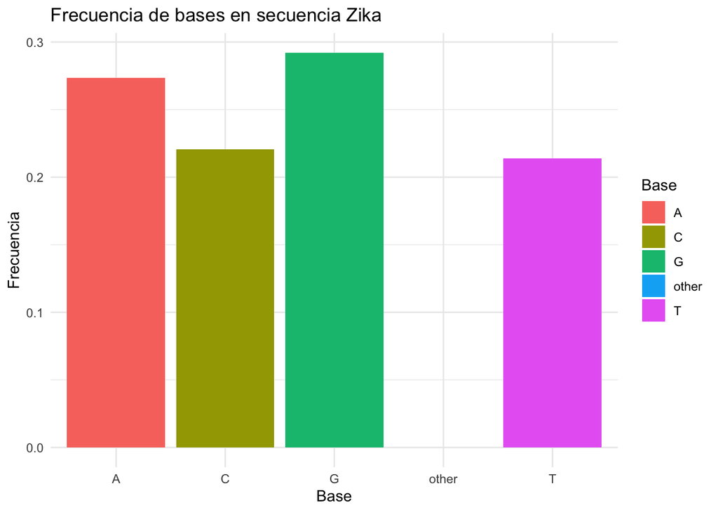

```r
ggplot(zika_df, aes(Base, Frecuencia, fill=Base))+
  geom_bar(stat="identity")+
  labs(title="Frecuencia de bases en secuencia Zika",
       x="Base", y="Frecuencia")+
  theme_minimal()
```

### SARS coronavirus

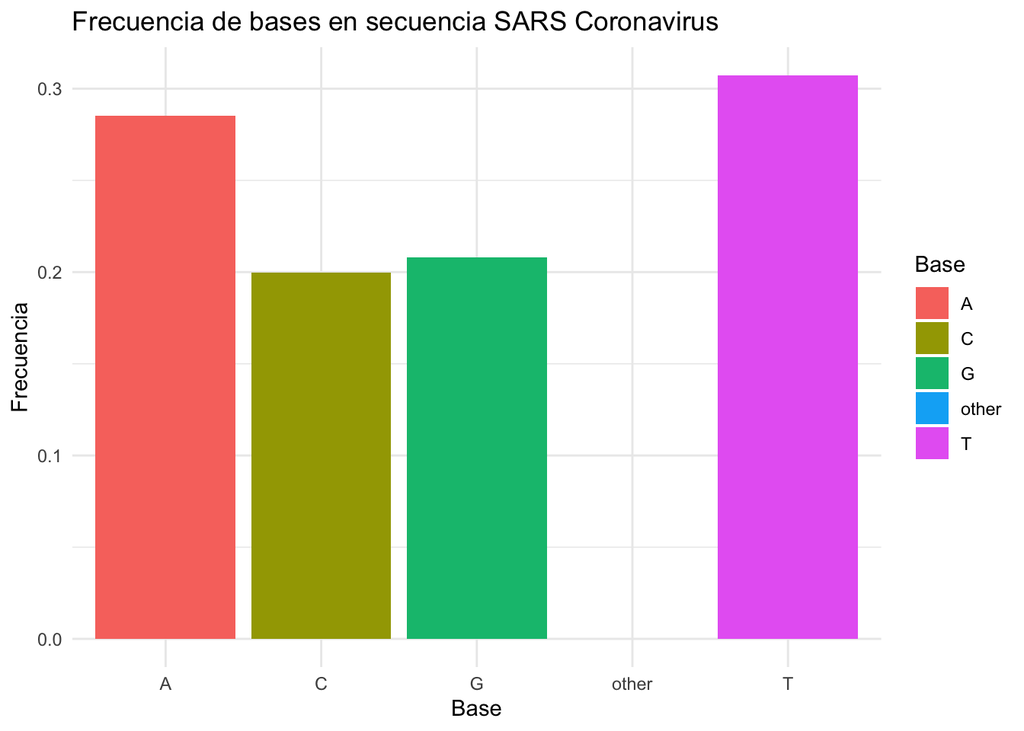

```r
ggplot(sars_df, aes(Base, Frecuencia, fill=Base))+
  geom_bar(stat="identity")+
  labs(title="Frecuencia de bases en secuencia SARS Coronavirus",
       x="Base", y="Frecuencia")+
  theme_minimal()
```

### Wuhan seafood market pneumonia virus isolate Wuhan-Hu-1

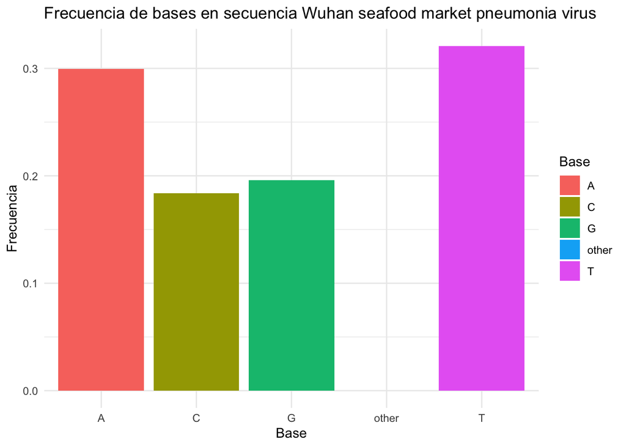

```r
ggplot(wuhan_df, aes(Base, Frecuencia, fill=Base))+
  geom_bar(stat="identity")+
  labs(title="Frecuencia de bases en secuencia Wuhan seafood market pneumonia virus",
       x="Base", y="Frecuencia")+
  theme_minimal()
```

### Middle East respiratory syndrome coronavirus

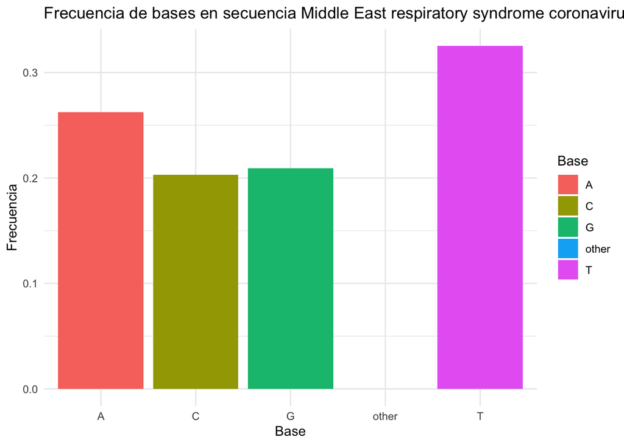

```r
ggplot(middle_east_df, aes(Base, Frecuencia, fill=Base))+
  geom_bar(stat="identity")+
  labs(title="Frecuencia de bases en secuencia Middle East respiratory syndrome coronavirus",
       x="Base", y="Frecuencia")+
  theme_minimal()
```

### Dengue virus 1

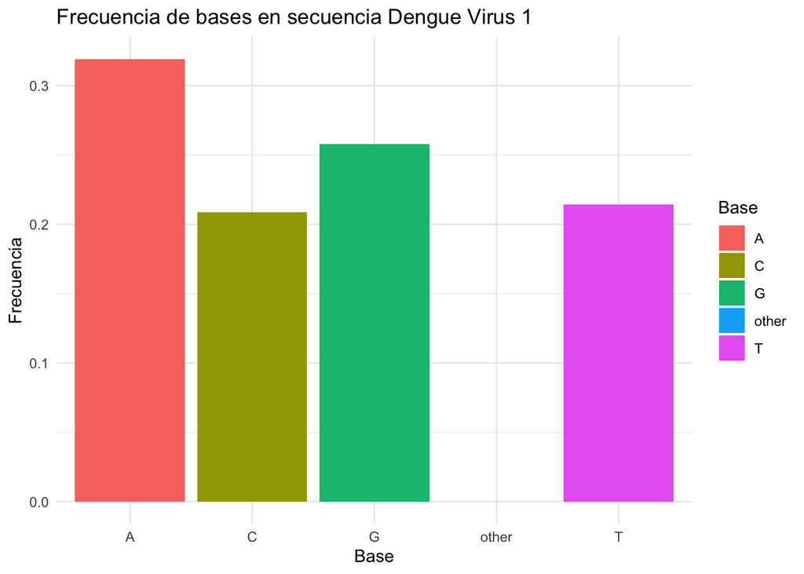

```r
ggplot(dengue_df, aes(Base, Frecuencia, fill=Base))+
  geom_bar(stat="identity")+
  labs(title="Frecuencia de bases en secuencia Dengue Virus 1",
       x="Base", y="Frecuencia")+
  theme_minimal()
```

### H1N1

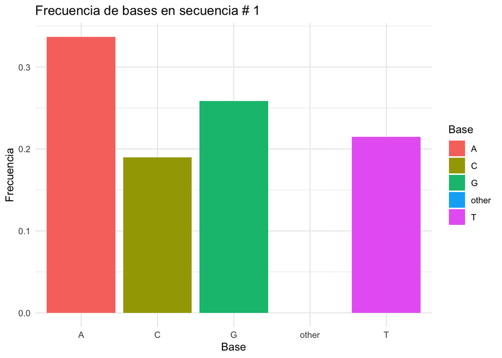

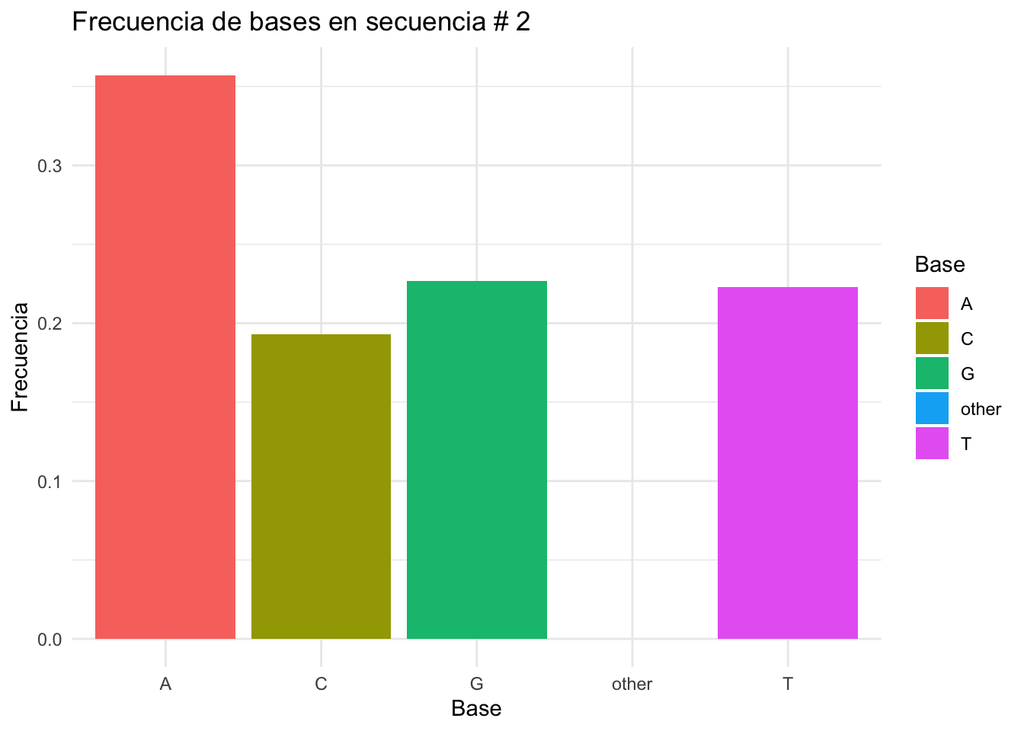

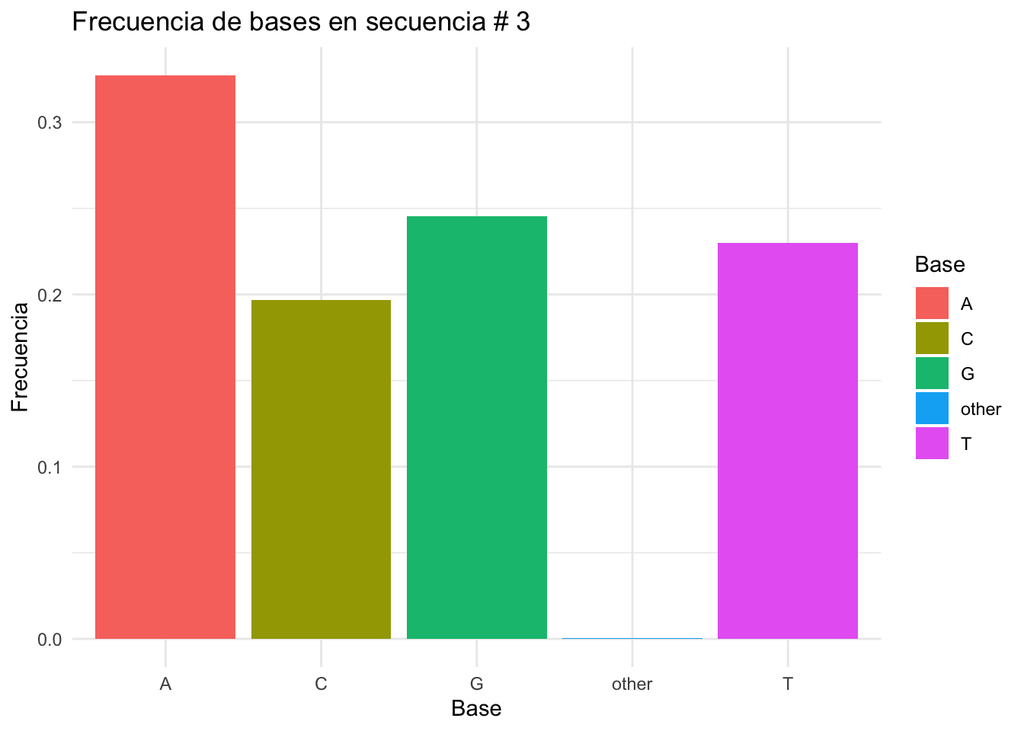

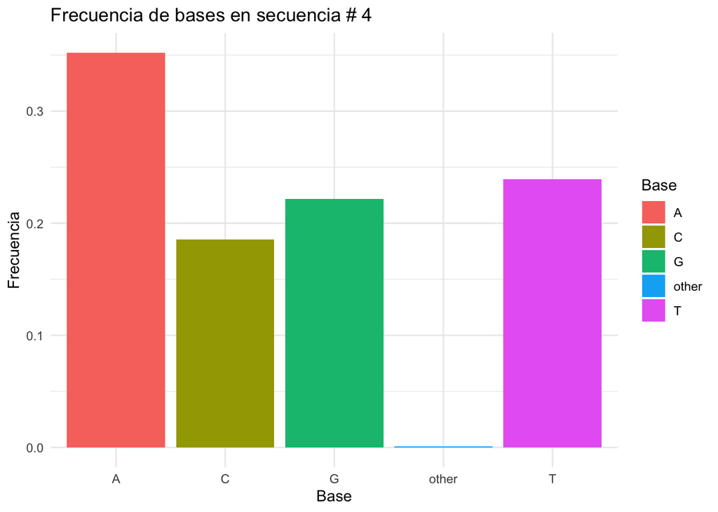

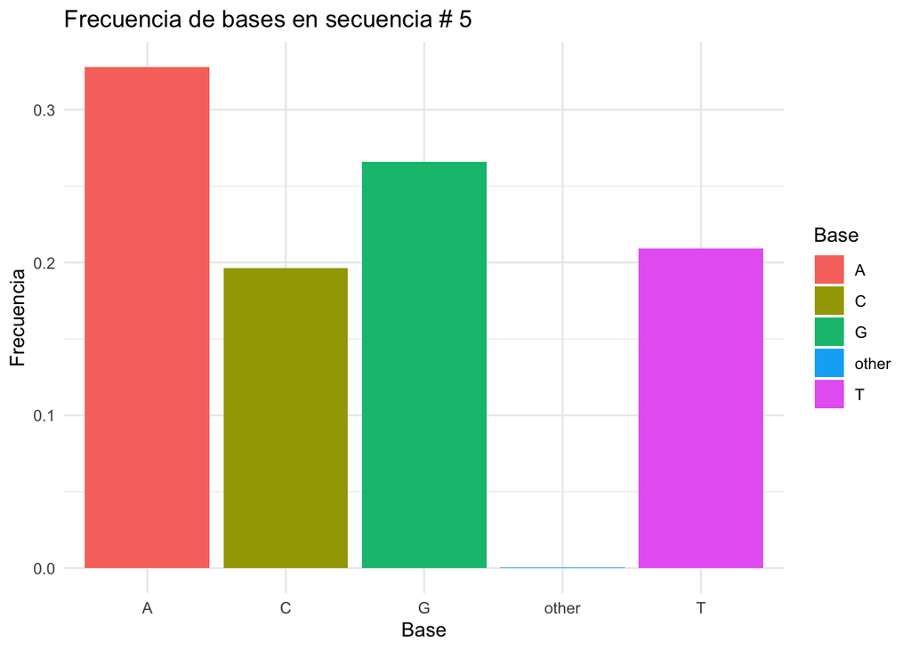

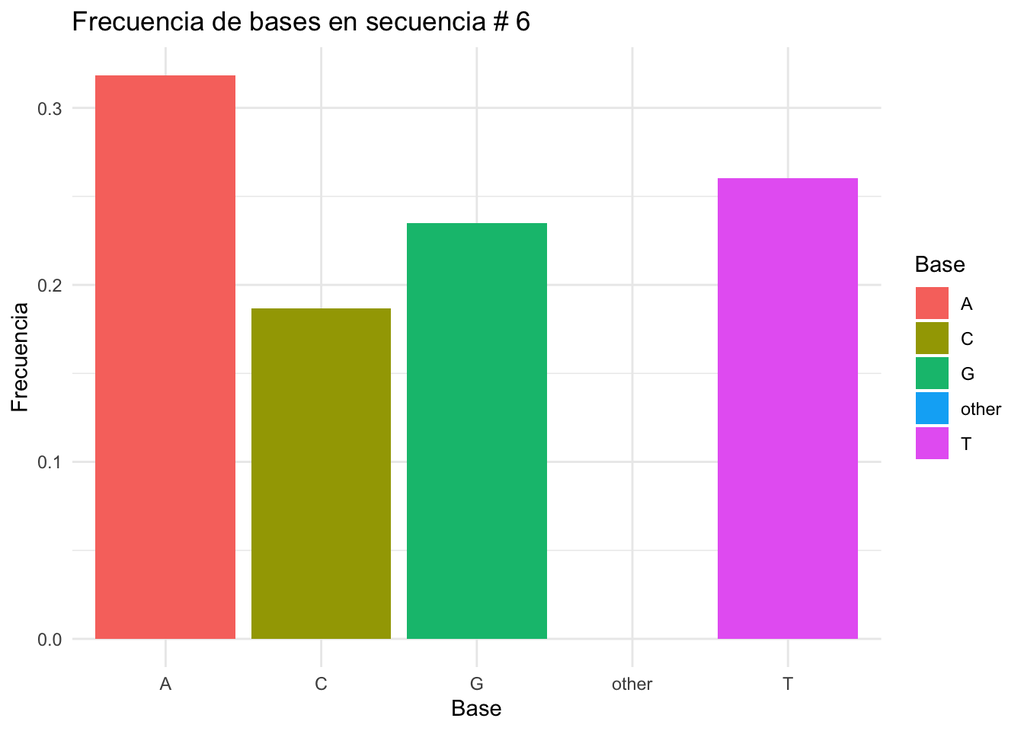

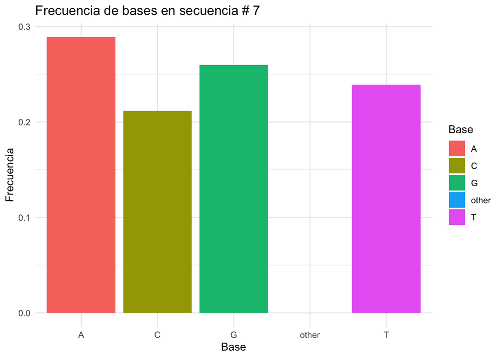

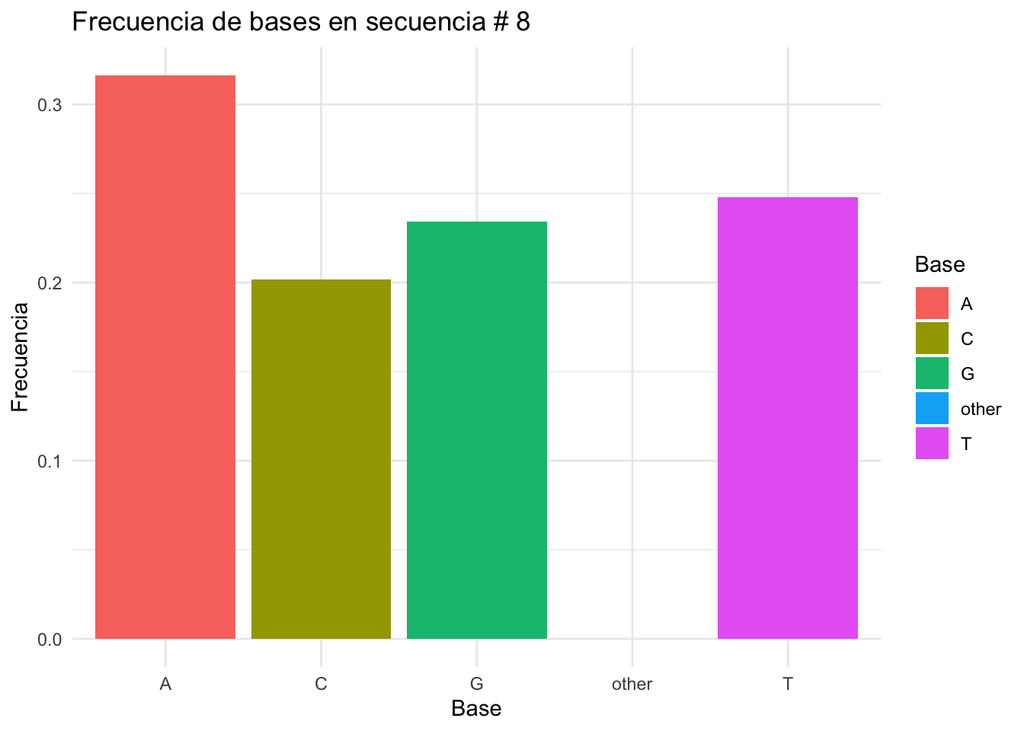

```r
h1n1_list <- vector("list", length = length(h1n1))
for (i in 1:length(h1n1)){
  print(
    ggplot(biodf(h1n1[[i]]), aes(Base, Frecuencia, fill=Base))+
    geom_bar(stat="identity")+
    labs(title=paste("Frecuencia de bases en secuencia #",i),
        x="Base", y="Frecuencia")+
    theme_minimal()
  )
}
```